# Simulation of Market Sales Variations

### 5.3.4 Further household model

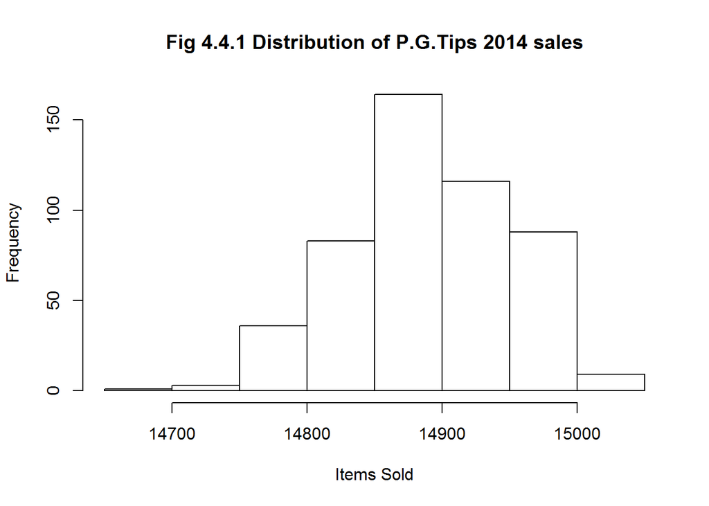

```r
hist(sim_new_share$P.G.Tips,main="Fig 4.4.1 Distribution of P.G.Tips 2014 sales",xlab="Items Sold")
```

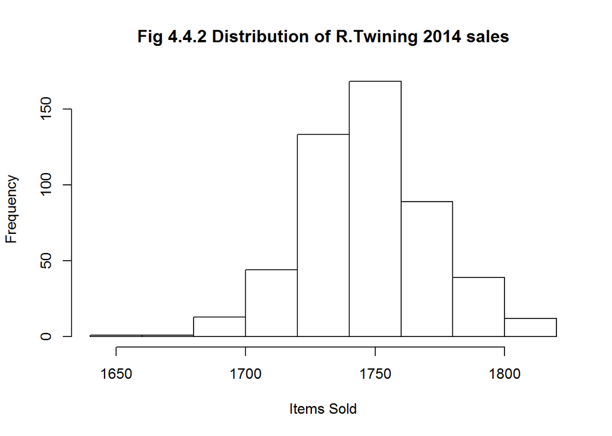

```r
hist(sim_new_share$R.Twining,main="Fig 4.4.2 Distribution of R.Twining 2014 sales",xlab="Items Sold")
```

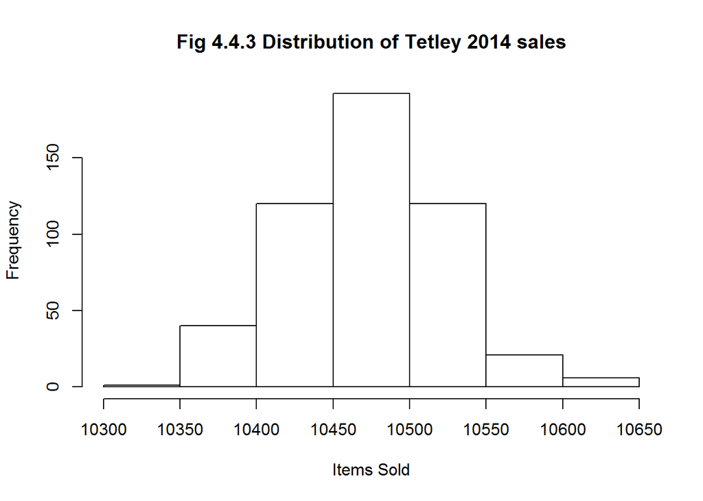

```r
hist(sim_new_share$Tetley.Standard.Bags,main="Fig 4.4.3 Distribution of Tetley 2014 sales",xlab="Items Sold")
```

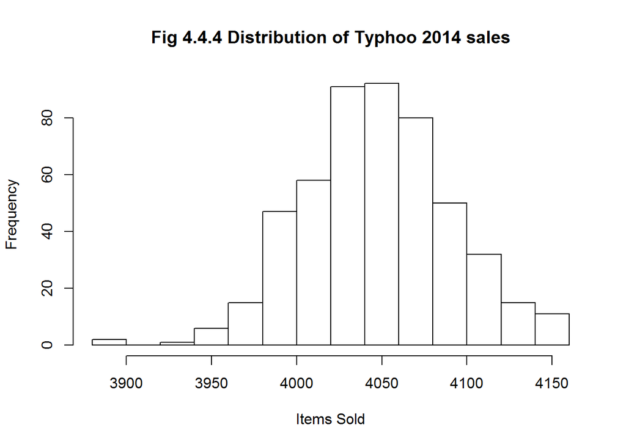

```r
hist(sim_new_share$Typhoo,main="Fig 4.4.4 Distribution of Typhoo 2014 sales",xlab="Items Sold")
```

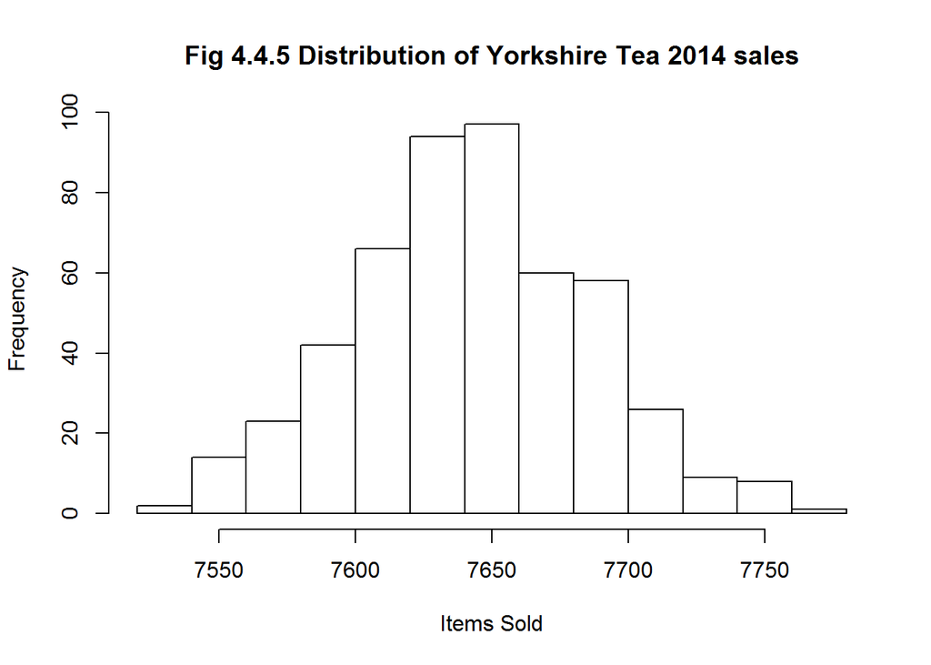

```r
hist(sim_new_share$Yorkshire.Tea,main="Fig 4.4.5 Distribution of Yorkshire Tea 2014 sales",xlab="Items Sold")
```

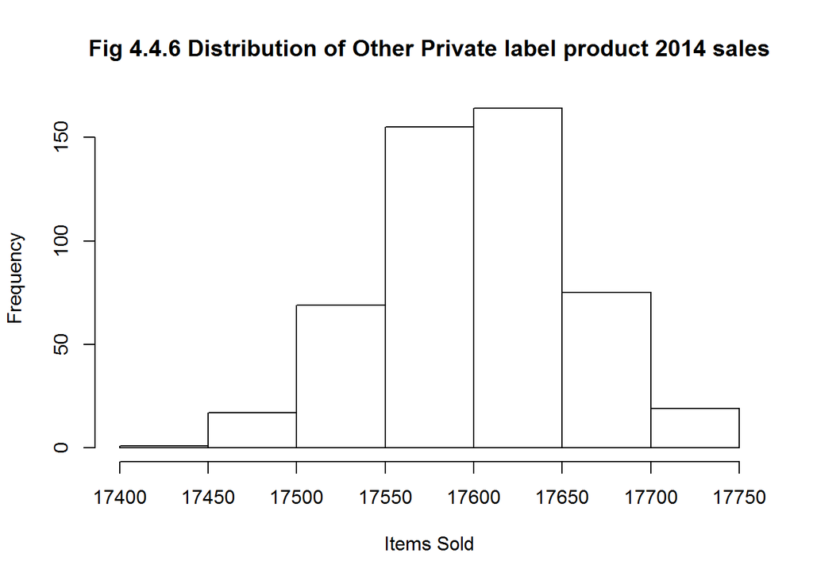

```r
hist(sim_new_share$others_PL,main="Fig 4.4.6 Distribution of Other Private label product 2014 sales",xlab="Items Sold")
```

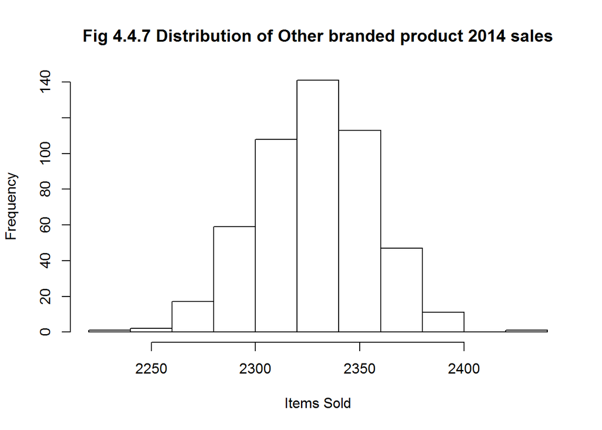

```r
hist(sim_new_share$others_BRD,main="Fig 4.4.7 Distribution of Other branded product 2014 sales",xlab="Items Sold")
```

## 5.4 Standard deviation of sales of different models

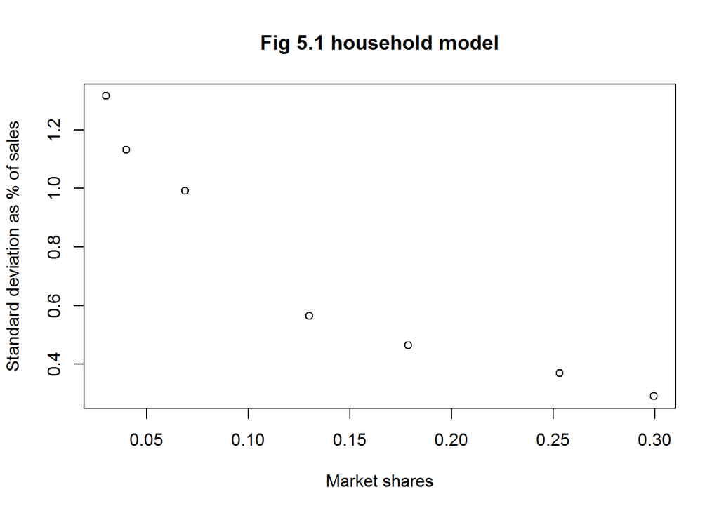

```r
plot(STAT_TABLE$MEAN/sum(STAT_TABLE$MEAN),STAT_TABLE$SD_percentage_mean,main="Fig 5.1 household model",ylab="Standard deviation as % of sales",xlab="Market shares")
```

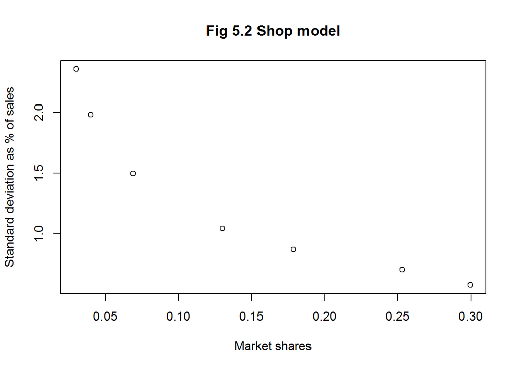

```r
plot(STAT_TABLE2$MEAN/sum(STAT_TABLE2$MEAN),STAT_TABLE2$SD_percentage_mean,main="Fig 5.2 Shop model",ylab="Standard deviation as % of sales",xlab="Market shares")
```

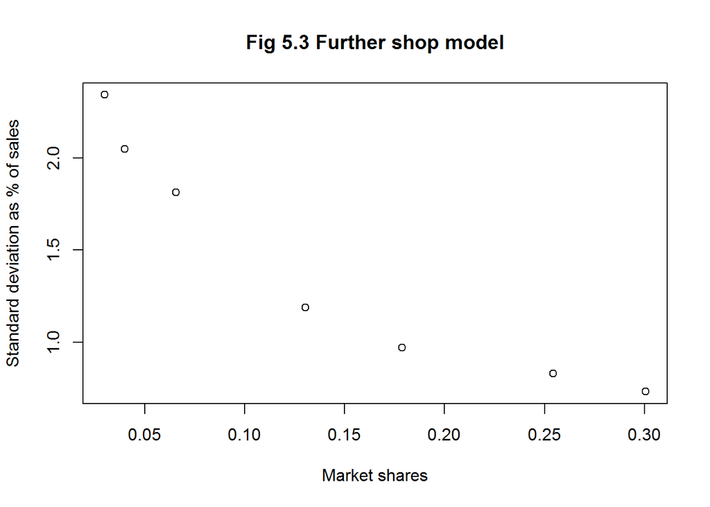

```r
plot(STAT_TABLE3$MEAN/sum(STAT_TABLE3$MEAN),STAT_TABLE3$SD_percentage_mean,main="Fig 5.3 Further shop model",ylab="Standard deviation as % of sales",xlab="Market shares")
```

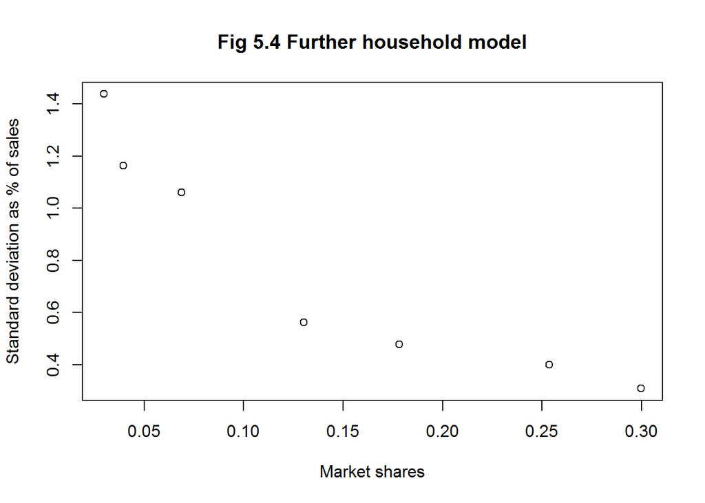

```r
plot(STAT_TABLE4$MEAN/sum(STAT_TABLE4$MEAN),STAT_TABLE4$SD_percentage_mean,main="Fig 5.4 Further household model",ylab="Standard deviation as % of sales",xlab="Market shares")
```

## 5.5 Increase in variance with higher aggregation level

Let the more aggregated model be a binomial distribution of power $n$ and probability $p$.

At a lower aggregation level, such distribution is broken down in to $I$ segments and the distributions within each segement $i$ be an indepentent binomial distribution of power $n_i$ with probability $p_i$.

The variance of the more aggregated model is,

$$np(1-p)$$
.

The by CLT[2], if $I$ is large enough, the variance of the segmented distribution sums up to be,

$$\Sigma_i^I n_ip_i(1-p_i)$$
,

where,

$$\Sigma_i^I n_i = n$$
and,

$$\Sigma_i^I n_ip_i=np$$
.

Then consider,

$$np(1-p)-\Sigma_i^I n_ip_i(1-p_i)$$
,

$$= \Sigma_i^I n_ip_i[(1-p)-(1-p_i)]$$
,

$$=\Sigma_i^I n_ip_i(p_i-p)$$
,

$$\geq \Sigma_i^I n_ip(p_i-p)$$
,

$$= p\Sigma_i^I n_i(p_i-p)$$
,

$$=0$$
. Q.E.D.